# Solution for Exam 2009 Problem 1

### 02409 Multivariate Statistics

`Week G`

The data are part of a study on two species of male flea-beetles: *Chaetocnema concinna* and *Chaetocnema heikertlinger*.

The variables are:

- species: “Conc” = *Chaetocnema concinna*, “Heik” = *Chaetocnema heikertlinger*
- number : observation number within species
- $x_{1}$ : width of the first joint of the first tarsus in microns (the sum of measurements for both tarsi)
- $x_{2}$ : the same for the second joint
- $x_{3}$ : the maximal width of the aedeagus in the fore-part in microns

We consider a linear discriminant analysis (LDA) with equal priors and losses.

```r
P1 <- data.frame("species" = c("conc","conc","conc","conc","conc","conc","conc","conc","conc","conc","conc","conc","conc","conc","conc","conc","conc","conc","conc","conc","conc","heik","heik","heik","heik","heik","heik","heik","heik","heik","heik","heik","heik","heik","heik","heik","heik","heik","heik","heik","heik","heik","heik","heik","heik","heik","heik","heik","heik","heik","heik","heik"),
                 "number" = c(1,2,3,4,5,6,7,8,9,10,11,12,13,14,15,16,17,18,19,20,21,1,2,3,4,5,6,7,8,9,10,11,12,13,14,15,16,17,18,19,20,21,22,23,24,25,26,27,28,29,30,31),
                 "x1" = c(191,185,200,173,171,160,188,186,174,163,190,174,201,190,182,184,177,178,210,182,186,186,211,201,242,184,211,217,223,208,199,211,218,203,192,195,211,187,192,223,188,216,185,178,187,187,201,187,210,196,195,187),
                 "x2" = c(131,134,137,127,118,118,134,129,131,115,143,131,130,133,130,131,127,126,140,121,136,107,122,114,131,108,118,122,127,125,124,129,126,122,116,123,122,123,109,124,114,120,114,119,111,112,130,120,119,114,110,124),
                 "x3" = c(53,50,52,50,49,47,54,51,52,47,52,50,51,53,51,51,49,53,54,51,56,49,49,47,54,43,51,49,51,50,46,49,49,49,49,47,48,47,46,53,48,50,46,47,49,49,54,47,50,51,49,49))
P1$species <- as.factor(P1$species)
```

We start by performing a discriminant analysis in R:

```r
prior = c(0.5,0.5)

# Linear discriminant analysis with x1, x2 and x3
discrim1 <- lda(species~.,data=P1[,-2],prior = prior)
```

## Question 1.1.

If we have equal dispersion/covariance matrix and we have equal priors, the Mahalanobis’ distance is equal to the squared generalized distance, and we can read it directly in the output:

```r
pcov = pooled.cov(as.matrix(P1[,c(3:5)]),P1$species)
invCov = solve(pcov)
Means = discrim1$means

maha = matrix(NA,ncol=2,nrow=2)
for (i in c(1:2)){
  for (j in c(1:2)){
    mu = Means[i,] - Means[j,]
    maha[i,j] = t(mu)%*%invCov%*%mu
  }
}
print("Generalized Squared Distances to species:")
maha
```

```
## [1] "Generalized Squared Distances to species:"
```

```
##          [,1]     [,2]
## [1,]  0.00000 15.07245
## [2,] 15.07245  0.00000
```

Answer 4

## Question 1.2.

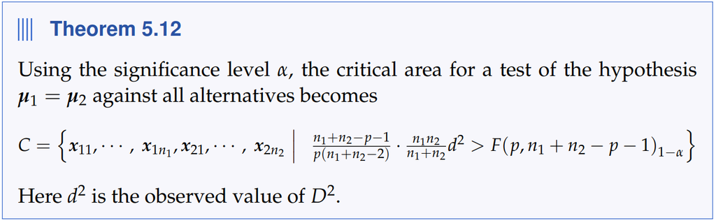

The relevant information is found in the output:

```r
# Theorem 5.12
# F(p, n1 + n2 - p - 1)
print("Class Level Information:")

data.frame("Frequency" = discrim1$counts,"Proportion"=discrim1$counts/discrim1$N,
           "Prior"=discrim1$prior)
```

```
## [1] "Class Level Information:"
```

```
##      Frequency Proportion Prior
## conc        21  0.4038462   0.5
## heik        31  0.5961538   0.5
```

Where we have 3 variable ($p$ = 3) and the group sizes are $n_1$ = 31 and $n_2$ = 21. We get:

$$F(p,n_1 + n_2 - p - 1) = F(3,31 + 21 - 3 - 1) = F(3,48)$$

```r
# In R:

p = 3 # x1,x2,x3
n1 = sum(P1$species=="conc")
n2 = sum(P1$species=="heik")

n1+n2-p-1
```

```
## [1] 48
```

The answer is thus 3.

The other approach is based on the test statistic for different means found on page 342 in the book:

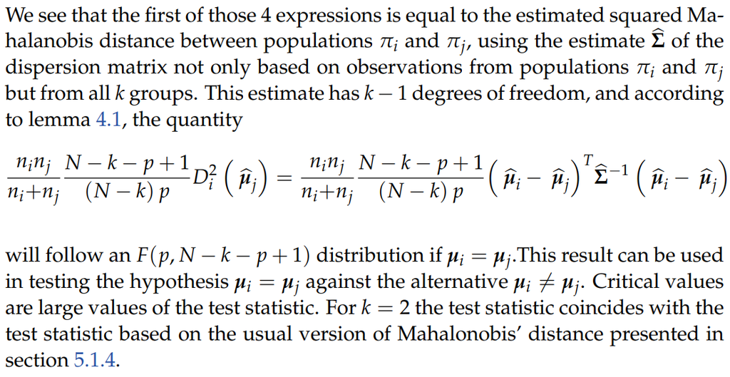

We have 3 variable ($p$=3), 2 groups (classes) the group sizes are $n_1$ = 31 and $n_2$ = 21 and the total sample size is thus 52 (which can also be read directly). We then have:

$$F(p,N - k - p + 1) = F(3,52 - 2 - 3 +1) = F(3,48)$$

## Question 1.3.

We refer to page 341:

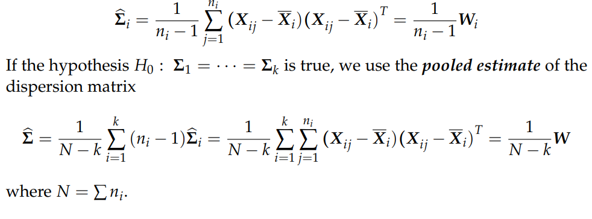

We thus have:

$$\hat{\Sigma}=\frac{1}{N-k}\left(\left(n_{1}-1\right)
\hat{\Sigma}_{1}+\left(n_{2}-1\right)
\hat{\Sigma}_{2}\right)=\frac{1}{31+21-2}\left((31-1)
\hat{\Sigma}_{1}+(21-1) \hat{\Sigma}_{2}\right)$$

The relevant numbers can be found in the output below:

```r
print("Within-Class Covariance Matrices")
print("species=Heik, DF=30:")
(pcov.h = pooled.cov(as.matrix(P1[P1$species=='heik',c(3:5)]),c(rep(1,n2))))
print("species=Conc, DF=20:")
(pcov.c = pooled.cov(as.matrix(P1[P1$species=='conc',c(3:5)]),c(rep(1,n1))))
print("Pooled Within-Class Covariance Matrix,DF=50:")
(pcov = pooled.cov(as.matrix(P1[,c(3:5)]),P1$species))
```

```
## [1] "Within-Class Covariance Matrices"
```

```
## [1] "species=Heik, DF=30:"
```

```
##          x1        x2        x3
## x1 222.1333 63.400000 22.600000
## x2  63.4000 44.159140  7.909677
## x3  22.6000  7.909677  5.516129
```

```
## [1] "species=Conc, DF=20:"
```

```
##           x1       x2        x3
## x1 147.49048 66.63810 18.526190
## x2  66.63810 51.24762 11.545238
## x3  18.52619 11.54524  4.990476
```

```
## [1] "Pooled Within-Class Covariance Matrix,DF=50:"
```

```
##           x1        x2        x3
## x1 192.27619 64.695238 20.970476
## x2  64.69524 46.994531  9.363902
## x3  20.97048  9.363902  5.305868
```

For $x_1$ we thus have:

$$\sigma_x^{2} = \frac{20 \cdot 147.49 + 30 \cdot 222.13}{31 + 21 -2} =
192.28$$

```r
# In R:
((n1-1)*pcov.c[1,1]+(n2-1)*pcov.h[1,1])/(31+21-2)
```

```
## [1] 192.2762
```

And the answer is 4

## Question 1.4.

To get the Linear Discriminant Function Coefficients, `linDA()` from the `DiscriMiner` library is used since the coefficients are not provided in the `lda()` function from the `MASS` library.

```r
lda.coef <- linDA(P1[,3:5],P1[,1],prior=prior)
# removing log(prior), see Definition 5.15
# if prior are equal, (+log(p)) is not needed.
lda.coef$functions[1,] = lda.coef$functions[1,] - log(prior)

print("Linear Discriminant Function for species:")
lda.coef$functions
```

```
## [1] "Linear Discriminant Function for species:"
```

```
##                  conc         heik
## constant -290.5807111 -245.9470751
## x1         -0.6532475   -0.2636257
## x2          1.8799125    1.3250513
## x3          8.9210080    7.9141954
```

We want to classify as “Conc” if larger than a specific value.

This is the same situation as on page 338:

$S_i^L (\boldsymbol{x}) = x^T \Sigma^{-1} \mu_i - \frac{1}{2} \mu_i^T \Sigma^{-1} \mu_i + \log(p_i)$

These are what is given from R in the output above. Further on page 338:

If there are only two groups we note that we choose group 1 if

$$S_1^L (\boldsymbol{x}) - S_2^L (\boldsymbol{x}) \geq 0 \Leftrightarrow
x^T \Sigma^{-1} (\mu_1 - \mu_2) - \frac{1}{2} \mu_1^T \Sigma^{-1} \mu_1
+ \frac{1}{2} \mu_2^T \Sigma^{-1} \mu_2 > \log\frac{p_2}{p_1}$$
i.e. the same results as in theorem 5.4.

Since we want to classify as “Conc” if larger than c, “Conc” should be our $S_1^{L}$.

Since we have equal priors and losses $\ln{\frac{p_2}{p_1}} = 0$. The “d” in the problem refers to this part $x^{T}\Sigma^{-1}\mu_i$, and we only need to consider the “Constant” terms, i.e those not dependent on x.

$-\frac{1}{2}\mu_1^{T}\Sigma^{-1}\mu_1 + \frac{1}{2}\mu_2^{T}\Sigma^{-1}\mu_2$

which is then the *c* in this question. We then have

$$-\frac{1}{2}\mu_1^{T}\Sigma^{-1}\mu_1 +
\frac{1}{2}\mu_2^{T}\Sigma^{-1}\mu_2 = -290.58071 + 245.94708 = -44.63$$

Which we now need to isolate on the right hand side, yielding $x^{T}\Sigma^{-1}(\mu_1 - \mu_2) \geq 44.63$

The answer is thus 2.

## Question 1.5.

We first need to know what generalized variance is. We refer to the definition 1.61 on page 58.

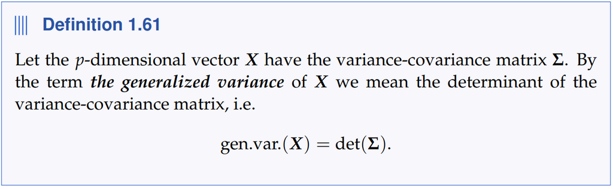

In the univariate case we have the concept of variance, which we generalize to the dispersion matrix in the multivariate case. The generalized variance is a way to boil down all the numbers in the dispersion matrix to one number. It is e.g. used when testing equivalence of dispersion matrices. Using R we find:

```r
Det = determinant(pcov)
print("Natural Log of the Determinant of the Covariance Matrix")
Det$modulus
print("gen.var.:")
exp(Det$modulus[1])
```

```
## [1] "Natural Log of the Determinant of the Covariance Matrix"
```

```
## [1] 9.519152
## attr(,"logarithm")
## [1] TRUE
```

```
## [1] "gen.var.:"
```

```
## [1] 13618.06
```

I.e. the logarithm of the generalized variance. To get the gen.var. we thus need to take the exponent:

$e^{9.51915} = 13618$, i.e. answer 1.

## Question 1.6.

*Omitted*